# Final Assignment

Heike Joana Wege

joana.wege@helsinki.fi

December 14, 2017

This page will contain my analysis with regard to the final assignment of the IODS-course, ongoing in the wintersemester 2017 at the University of Helsinki.

# Summary of this work:

In this final assignment I explore the fa_human dataset that I have established out of the Human Development Index and the Gender Inequality Index. Please see the section on [Datawrangling and Explanation of the Dataset](https://joawe.github.io/IODS-final/#datawrangling-and-explanation-of-the-dataset) for more information. Of particular interest to me appeared the variable that represents the maternal mortality rate.

I have attempted to relate this variable in diffenrent ways to the life-expectancy and the level of education.

The link to my coding of the datawrangling can be found from [here](https://github.com/JoaWe/IODS-final/blob/master/create_fa_human.R).

# Datawrangling and Explanation of the Dataset

The dataset that is used here is a modified combination of the [Human Development Index](http://hdr.undp.org/en/content/human-development-index-hdi) and the [Gender Inequality Index](http://hdr.undp.org/en/content/gender-inequality-index-gii) published by the United Nations Development Programme for the year 2016.

The datasets contained originally 8 variables for the Human Development Index and 10 for the Gender Inequality Index. Either set presented a total of 195 observations for most of the world’s countries and 7 regions.

However, the dataset used here has been - as mentioned above - modified by means of datawrangling with RStudio. The dataset now contains 155 observations and 8 variables:

1. **Life_Exp**, which refers to the average number of years of life-espectancy of a country’s population
2. **Exp_Edu**, which refers to the expected number of school years of a country’s population
3. **GNI**, which refers to the respective country’s gross domestic product
4. **MMR**, which refers to a country’s maternal mortality ratio in terms of deaths per 100,000 live births
5. **ABR**, which refers to a country’s respective Ratio of births given by adolescents, in terms of births per 1,000 women between the ages of 15 to 19
6. **PRP**, which refers to the share of parliamentary seats held by women in percent
7. **sec_Edu**, which refers to the population aged 25 or above with at least some secondary education in a country presented in percent
8. **LF**, which refers to the Labour force participation rate of a countries population (15 years of age or older)

The link to my coding of the datawrangling can be found from [here](https://github.com/JoaWe/IODS-final/blob/master/create_fa_human.R).

The modifications are as follows:

1. The variable-names have been shortened.
2. The two separate datasets have been joined by the variable “Country”, which existed in both datasets, and has later been used to replace the rownames.
3. The 7 regions have been removed from the dataset, resulting in a dataset containing only country-observations.
4. Missing values have been removed from the dataset, so that the dataset contains only complete sets.
5. The rows of the dataset have been sorted by the observations of the variable “GNI”

```r
# accessing libraries
library(dplyr)
# loading human:
fa_human <- read.table("C:\\Users\\Ani\\Documents\\GitHub\\IODS-final\\fa_human.csv", sep = ",", header = TRUE, row.names = 1)
```

In order to give a general overview over the data, you can see the summary and a simple plot here:

```r
# Accessing libraries for plots:
library(GGally)
library(corrplot)
# Summarizing the dataset for a brief overview:
summary(fa_human)
```

```
##     Life_Exp        Exp_Edu           GNI              MMR
##  Min.   :49.00   Min.   : 5.40   Min.   :  2.00   Min.   :   1.0
##  1st Qu.:66.30   1st Qu.:11.25   1st Qu.: 53.50   1st Qu.:  11.5
##  Median :74.20   Median :13.50   Median : 99.00   Median :  49.0
##  Mean   :71.65   Mean   :13.18   Mean   : 98.73   Mean   : 149.1
##  3rd Qu.:77.25   3rd Qu.:15.20   3rd Qu.:143.50   3rd Qu.: 190.0
##  Max.   :83.50   Max.   :20.20   Max.   :194.00   Max.   :1100.0
##       ABR              PRP           sec_Edu             LF
##  Min.   :  0.60   Min.   : 0.00   Min.   :0.1717   Min.   :0.1857
##  1st Qu.: 12.65   1st Qu.:12.40   1st Qu.:0.7264   1st Qu.:0.5984
##  Median : 33.60   Median :19.30   Median :0.9375   Median :0.7535
##  Mean   : 47.16   Mean   :20.91   Mean   :0.8529   Mean   :0.7074
##  3rd Qu.: 71.95   3rd Qu.:27.95   3rd Qu.:0.9968   3rd Qu.:0.8535
##  Max.   :204.80   Max.   :57.50   Max.   :1.4967   Max.   :1.0380
```

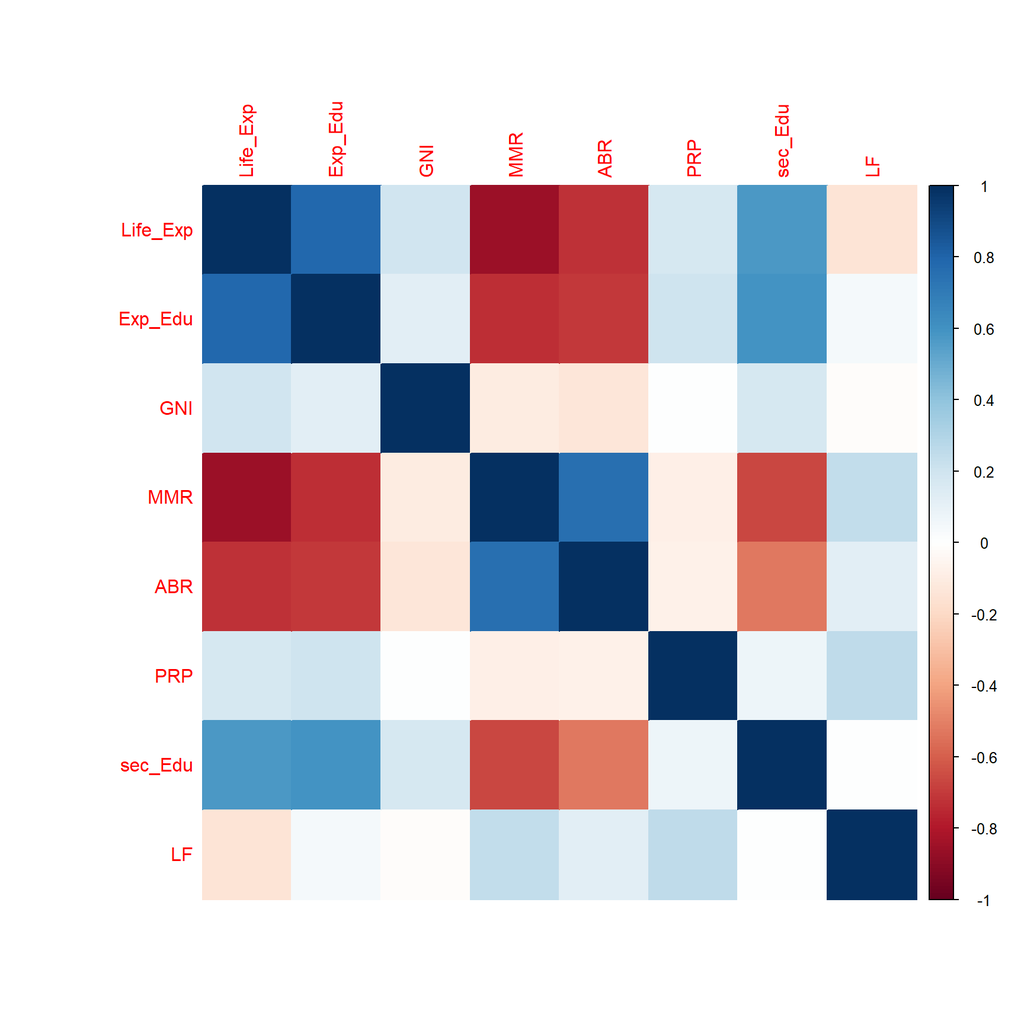

```r
# using corrplot to visualize the dataset in a simple manner:
cor(fa_human)%>%corrplot(method = "color")
```

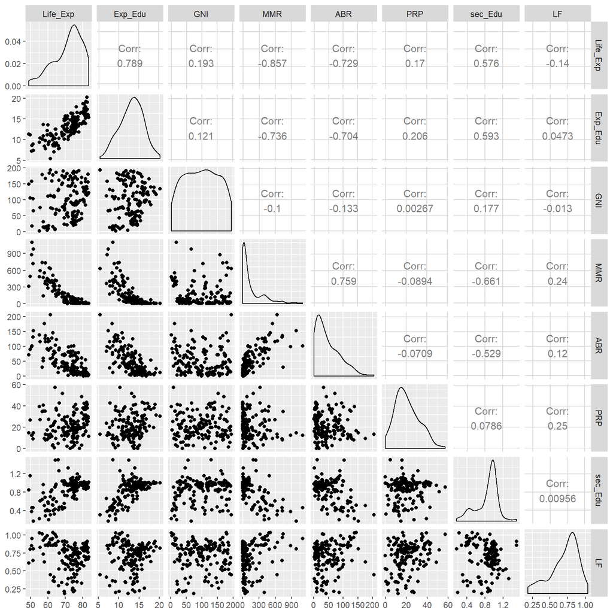

```r
# using ggpairs for more extensive visualization of the dataset:
ggpairs(fa_human)
```

*The first plot is to be read by the shades of red (= negative correlation) and blue (positive correlation). The darker the respective shade the stronger the supposed correlation.The second plot shows the correlation-coefficiants between the variables on the right upper side. The left lower side provides a rough overview of the dispersion of the respective observations.*

As can be seen from the plots above the maternal mortality rate appears (MMR) to be having a particularly obvious negative correlation with the average life-expectancy (Life_Exp), the expected years of education (Exp_Edu), and a population with at least some degree of secondary education (sec_Edu).

A strong positive correlation appears to be existing between the maternal mortality rate and the adolescent birthrate (ABR). Similarly positive appears to be the impact between the variables of expected education and the life-expectancy.

And finally, slightly weaker, yet still obvious appears to be the positive correlation between at least some degree of secondary education to the variables life-expectancy and expected years of education.

Accordingly, it appears to be sensible to take a few of these variables and their relationships under closer scrutiny.

# Hypotheses

1. The variables Life_Exp and MMR are strongly negatively correlated: **It can therefore be assumed that countries with a lower maternal mortality rate will display a higher life-expectancy in years.** Simple linear & logistic regression models ought to show the truth or falsehood of this hypothesis. It may also be interesting to see, which might fit more.
2. The variables Exp_Edu and sec_Eduare strongly negatively correlated with the variable MMR: **It can be assumed that an increase of education can have a decreasing effect on the maternal mortality rate**. Similarly as before, linear and logistic regression models ought to be sufficient to prove or disprove the hypothesis. Yet, the results ought to differ at least a little from the former hypothesis, as in this case the models will be based on multiple regression.

# 1. Life-Expectancy & Maternel Mortality Rate

### Basic Hypothesis:

**Countries with a lower mortality rate are expected to display a higher average life-expectancy.**

### Method: Linear Regression:

Linear regression analysis is used in order to relate to variables with one another. The independent variable thereby is believed to be the cause for the dependent variable, leading to the understanding that *if **x**, then **y*** .

A line is thereby drawn that - hopefully - fits as many observations as possible onto itself. Yet, in reality, the coinciding of all observations with *one particular line* is rather unlikely. Thus, the line is sought that is closest to at least most of the observations. Another problem might be, however, that more than one line can be correct.

The basic formular for this line is considered to be **y = a + bx**. The parameter **a** defines the line’s y-intercept, while **b** determines the line’s slope.

#### Applying Linear Regression Analysis:

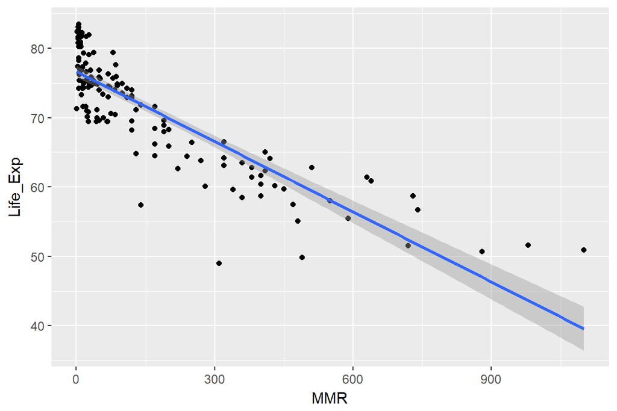

```r
# Accessing library:
library(ggplot2)

# drawing the plot:
qplot(MMR, Life_Exp, data = fa_human) + geom_smooth(method = "lm")
```

```r
# fitting the linear model:
Life_MDeath <- lm(MMR ~ Life_Exp, data = fa_human)

# Printing the model's summary
summary(Life_MDeath)
```

```
##
## Call:
## lm(formula = MMR ~ Life_Exp, data = fa_human)
##
## Residuals:
##     Min      1Q  Median      3Q     Max
## -332.66  -55.76   -9.74   57.25  498.74
##
## Coefficients:
##             Estimate Std. Error t value Pr(>|t|)
## (Intercept) 1710.274     76.345   22.40   <2e-16 ***
## Life_Exp     -21.788      1.058  -20.59   <2e-16 ***
## ---
## Signif. codes:  0 '***' 0.001 '**' 0.01 '*' 0.05 '.' 0.1 ' ' 1
##
## Residual standard error: 109.4 on 153 degrees of freedom
## Multiple R-squared:  0.7347, Adjusted R-squared:  0.733
## F-statistic: 423.8 on 1 and 153 DF,  p-value: < 2.2e-16
```

With regard to the graph above, the line is “falling” the further the observations get away from the y-axis (meaning an increase in the independent variable). Thus, the above hypothesis can be considered as “not being wrong”: The higher the maternal mortality rate is, the lower is the life-expectancy.

I chose the term “not wrong” intentionally for expressing the hypothesis’ validity, however, because when focusing on the graph, it does show that quite a number of observations is not even remotely found near the line. Which is why the summary helps to further analyze the results.

Of particular interest is, for instance, the multiple *r-sqared*, which if it were in perfect synchronization, were to reach the value of 1. In the case of this analysis, however, it reaches 0,7347. Thus, it implies that less than 75% (73,47%) of the variablity is explained by this linear regression model.

It remains to be seen, if the logistic regresssion might not lead to a more suitable result.

### Method: Logistic Regression:

The basis of logistic regression is the same as linear regression: An independent variable is drawn upon, in order to explain a dependent variable.

#### Applying Logistic Regression:

```r
# Accessing libraries:
library(tidyr)

# fitting the logistic model:
Life_MDeath_log <- glm(MMR ~ Life_Exp, data = fa_human)

# Printing the model's summary
summary(Life_MDeath_log)
```

```
##
## Call:
## glm(formula = MMR ~ Life_Exp, data = fa_human)
##
## Deviance Residuals:
##     Min       1Q   Median       3Q      Max
## -332.66   -55.76    -9.74    57.25   498.74
##
## Coefficients:
##             Estimate Std. Error t value Pr(>|t|)
## (Intercept) 1710.274     76.345   22.40   <2e-16 ***
## Life_Exp     -21.788      1.058  -20.59   <2e-16 ***
## ---
## Signif. codes:  0 '***' 0.001 '**' 0.01 '*' 0.05 '.' 0.1 ' ' 1
##
## (Dispersion parameter for gaussian family taken to be 11976.06)
##
##     Null deviance: 6907644  on 154  degrees of freedom
## Residual deviance: 1832338  on 153  degrees of freedom
## AIC: 1899.4
##
## Number of Fisher Scoring iterations: 2
```

The negative coefficient confirms the negative correlation between the variables. Meaning that, for example, it is likely that the life-expectancy is likely to increase if the maternal mortality rate were to got down. The value itself implies a high significance.

# 2. Maternal Mortality and Education

### Basic Hypothesis:

**An increase of education can have a decreasing effect on the maternal mortality rate.**

- **dependent variable = MMR**
- **1. independent variable = sec_Edu**
- **2. independent variable = Exp_Edu**

```r
# Accessing libraries:
library(tidyr)
library(ggplot2)

# fitting the logistic model:
Edu_MDeath_expo <- glm(MMR ~ sec_Edu + Exp_Edu, data = fa_human)

# Printing the model's summary
summary(Edu_MDeath_expo)
```

```
##
## Call:
## glm(formula = MMR ~ sec_Edu + Exp_Edu, data = fa_human)
##
## Deviance Residuals:
##     Min       1Q   Median       3Q      Max
## -323.46   -77.31   -11.78    40.52   650.97
##
## Coefficients:
##             Estimate Std. Error t value Pr(>|t|)
## (Intercept)  928.944     51.343  18.093  < 2e-16 ***
## sec_Edu     -303.595     54.509  -5.570 1.13e-07 ***
## Exp_Edu      -39.536      4.637  -8.525 1.41e-14 ***
## ---
## Signif. codes:  0 '***' 0.001 '**' 0.01 '*' 0.05 '.' 0.1 ' ' 1
##
## (Dispersion parameter for gaussian family taken to be 17313.97)
##
##     Null deviance: 6907644  on 154  degrees of freedom
## Residual deviance: 2631724  on 152  degrees of freedom
## AIC: 1957.5
##
## Number of Fisher Scoring iterations: 2
```

# Discussion

The brief analyses above have demonstarted that maternal mortality is both a driver, as well as, a result of living conditions and opportunities of individuals.

With regard to the question of life-expectancy the maternal mortality rate is a driver, that affects the average life-expectancy of a population negatively. It might be argued that it is an obvious - or at least to be expected - result, particularly as a woman’s age for getting pregnant and giving birth rarely reaches the higher age-groups. Yet, especially with regard to this “taken-for-grantedness” it might be necessary to actually visualize that problem.